# **Overwatch League 2019 Visualization & Analysis**

[figure not shown]

## Background

Overwatch is a 6-a-side online team-based first-person shooter (fps) game in which two teams battle to achieve victory over each other by collectively competing to complete a set objective. Players on each team pick a unique character or **‘hero’** (limited to one each per team), from a roster of 30 (as of 2019).

Characters are categorized into 3 groups depending upon their designed role in a team:  
**Tanks** survive longer and protect teammates from damage,  
**Healers** restore the health of teammates, and  
**Damage** are designed to be more mobile and deal higher damage to enemy heroes.

## Data Origins and Research Questions

The dataset was obtained from [Overwatch League Statslab](https://www.overwatchleague.com/en-us/statstab) and contains in-game stat data collected during the **Overwatch league (OWL)** 2019 professional esports tournament; including a record of how long each hero was played for by each player in each tournament match, which indicates the popularity of the character in the **‘meta’** - the generally agreed upon best strategy.

The game’s esports scene reached peak popularity around 2018-19, during which time a specific composition of heroes, termed **GOATS** (after the North American team which discovered it), was found to be most optimal and became the popular choice for professional teams. This composition composed of 3 tanks, and 3 healers, neglecting mobile dps characters in favor of raw survivability. This was controversial as most of these heroes required less skill at aiming - a central part of most fps games.

The dominance of this composition triggered a wave of attempts by the developers of the game to decrease the power of the heroes within GOATS during 2019, culminating with the introduction of a ‘role lock’ in 2020; whereby, each team was limited to picking 2 heroes from each group. The game experienced a sudden decline in popularity going into 2020, believed to be primarily due to this change, thus it is important to review if this was indeed a necessary change, or a bad decision by the developers.

#### Project Aim

The primary aim of this project is to visualize the distribution of hero popularity, and formation of a meta (or most popular strategy) during the **OWL** 2019 tournament, in order to see the effect on hero pick variety.

*note: the acronyms OWL and GOATS are unrelated to the animals*

### Data Description:

A codebook describing variables and functions within this project is located at /codebook.txt, and a description of csv data column titles is located in /data/rawdata/datasource.txt

## Data Preparation

### Loading Packages

The renv package was used to store package versions used for the project, preventing future package updates from breaking the project.

Package versions used in this project are listed within the file /renv.lock

```r
#Load packages with renv
install.packages("renv")
library(renv)
renv::restore()

#Import packages
library(tidyverse)
library(ggplot2)
library(here)
library(readr)
library(showtext)
```

### Combining data

The dataset consists of three separate csv files, so the initial step was to combine these into a single dataframe to facilitate simpler and easier data retrieval.

```r
#Read raw data files and combine into a single csv file
combinedData <- list.files(path = here("data", "rawdata"),
                           pattern = "*.csv", full.names = TRUE) %>%
  lapply(read_csv) %>%
  bind_rows

#Save combined data set
combinedData_FileName = paste(here("data"), "/phs_2019_combined.csv", sep = "")
write.csv(combinedData, combinedData_FileName)   #Write dataset to new .csv in /data

combinedData
```

| start_time | match_id | stage | map_type | map_name | player | team | stat_name | hero | stat_amount |
| --- | --- | --- | --- | --- | --- | --- | --- | --- | --- |
| 2/15/2019 0:11 | 21211 | Overwatch League Stage 1 | CONTROL | Ilios | Bdosin | London Spitfire | All Damage Done | All Heroes | 1.484519e+04 |
| 2/15/2019 0:11 | 21211 | Overwatch League Stage 1 | CONTROL | Ilios | Bdosin | London Spitfire | Assists | All Heroes | 1.300000e+01 |
| 2/15/2019 0:11 | 21211 | Overwatch League Stage 1 | CONTROL | Ilios | Bdosin | London Spitfire | Average Time Alive | All Heroes | 8.762357e+01 |
| 2/15/2019 0:11 | 21211 | Overwatch League Stage 1 | CONTROL | Ilios | Bdosin | London Spitfire | Barrier Damage Done | All Heroes | 5.674344e+03 |
| 2/15/2019 0:11 | 21211 | Overwatch League Stage 1 | CONTROL | Ilios | Bdosin | London Spitfire | Damage - Quick Melee | All Heroes | 7.800000e+01 |
| 2/15/2019 0:11 | 21211 | Overwatch League Stage 1 | CONTROL | Ilios | Bdosin | London Spitfire | Damage Done | All Heroes | 9.039330e+03 |
| 2/15/2019 0:11 | 21211 | Overwatch League Stage 1 | CONTROL | Ilios | Bdosin | London Spitfire | Damage Taken | All Heroes | 4.192611e+03 |
| 2/15/2019 0:11 | 21211 | Overwatch League Stage 1 | CONTROL | Ilios | Bdosin | London Spitfire | Deaths | All Heroes | 4.000000e+00 |
| 2/15/2019 0:11 | 21211 | Overwatch League Stage 1 | CONTROL | Ilios | Bdosin | London Spitfire | Defensive Assists | All Heroes | 2.100000e+01 |
| 2/15/2019 0:11 | 21211 | Overwatch League Stage 1 | CONTROL | Ilios | Bdosin | London Spitfire | Eliminations | All Heroes | 1.800000e+01 |

[output cut: 9990 more lines]

### Removing unwanted data

The combined dataset contains a large amount of unnecessary information; thus, it was cleaned by extracting required data to a new data frame. This increases readability and decreases data frame processing time.

Furthermore, the play_time data was converted from seconds to hours to increase readability of the final visualisation. This code was saved as a function, allowing it to be used on differently grouped data later in the project.

```r
#Obtain data to plot hero playtime
heroData <- combinedData[combinedData$hero != "All Heroes", ]   #Remove rows with "All Heroes" in hero column

playTimeData <- heroData[heroData$stat_name == "Time Played", ] %>%   #Remove rows without "Time Played" in stat_name column
  group_by(hero) %>%   #Sum playtime for each hero
  summarise(play_time = sum(stat_amount)) %>%
  ungroup()

#Creates the function clean_pt; which, reorders and converts play time data into hours
clean_pt <- function(df){
    df %>%
    arrange(., desc(play_time)) %>%                                   #Arrange rows by descending value of play_time
    mutate(play_time = play_time/3600) %>%                            #Convert play_time from seconds to hours and round to the nearest whole number
    mutate(rounded_play_time = round(play_time)) %>%
    transform(rounded_play_time = as.character(rounded_play_time))
}

playTimeData <- clean_pt(playTimeData)
```

## Visualisation

### Colours

Colours of bars in the visualisation correspond to colours of the heroes within the game, increasing glance value for those familiar with the game. This is important as those most likely to be interested in the data are those familiar with the game.

Some colours with low contrast to the white plot background were increased in saturation to facilitate easier plot reading.

```r
#Aesthetics for graph
  #Retrieve colour associated with each hero and add to playTimeData df as column hero_colour
heroColourLocation <- here("data", "hero_colours.csv")
heroColourData <- read.csv(file = heroColourLocation, encoding = "UTF-8")
colnames(heroColourData)[1] <- gsub('^.........','',colnames(heroColourData)[1])   #Fix error with imported column name

#Creates the function add_colour; which, for each hero in the dataframe, writes the related colour hex value to a column called hero_colour
add_colour <- function(df){
i = 0
  for (h in df$hero){
    i = i + 1
    hrow <- which(heroColourData$hero == h)
    df$hero_colour[i] <- paste(heroColourData$hex_value[hrow])
  }
  df
}

playTimeData <- add_colour(playTimeData)
```

### Custom Text

A custom text was imported and applied to the visualisation using the showtext package. The font is similar to fonts used within the game, making the visualisation appear more professional and/or official, while increasing overall appeal.

```r
#Load new custom font for showtext package
font_add_google(name = "Bebas Neue", family = "Bebas Neue")
showtext_auto()
```

### Graph Design Variables

Similar graph and theme options, which were used multiple times within the code, were saved as variables to facilitate easier adjustment.

```r
#Define graph aesthetic variables
backgroundColour = "white"
textColour = "#5c5c5c"
textColourFaded = "#5c5c5c8a"
barLabelSize = 11
```

### Bar Plot

A bar chart was most appropriate for the data to compare a grouped continuous variable. Furthermore, it is simple and commonly used, increasing ease of data interpretation.

Only 15 out of the 30 heroes were included in the plot in order to increase visual clarity; while the idea that the visualization portrays was maintained by ordering heroes by play time. This allows the distribution of the hero ‘popularity ranking’ to be visualized to see if a meta had formed (suggested by a non-smooth distribution, dominated by a few popular heroes).

```r
#Define data to plot
nheros <- 15:1   #Define number of heroes to show on graph
hpt <- ggplot(playTimeData[nheros,], aes(x = hero, y = play_time, fill = hero))   #Assign hero play time plot data to a variable

#Align text bar label with numerical bar label. Two labels are used to allow font size difference
i = 0
hourLabel <- c(0)
for (i in nheros){   #If playtime has more than 2 digits, increases spacing of HOURS label to align with numerical bar label
  hourLabel[i] <- "HOURS"
  if (playTimeData$play_time[i] > 99){
    hourLabel[i] <- "  HOURS"
  }
}

playTimeData
```

| hero | play_time | rounded_play_time | hero_colour |
| --- | --- | --- | --- |
| Lúcio | 346.1249785 | 346 | #76bd39 |
| Brigitte | 323.6589528 | 324 | #be736e |
| Zarya | 312.2341129 | 312 | #e675b1 |
| D.Va | 309.8198298 | 310 | #f0a1ce |
| Zenyatta | 284.5891655 | 285 | #e6d663 |
| Reinhardt | 261.9870275 | 262 | #929da3 |
| Sombra | 116.0849891 | 116 | #7359ba |
| Ana | 102.3514843 | 102 | #8fabd9 |
| Winston | 74.0649099 | 74 | #586f8c |
| Mercy | 60.7776106 | 61 | #dbd286 |

[output cut: 20 more lines]

### Design

A minimalist and clean design was used to reduce clutter, emphasizing clarity while maintaining a modern appeal.

Text contrast with the background is used to guide the viewer to important information, such as the title and hero names. Less contrasting colour values are used for less important information. If the viewer is specifically looking for this information they will be able to find it, but lowered contrast prevents it becoming overbearing to the clarity of the overall design.

Bar labels allow for accurate data readings while reducing the number of axis ticks required, allowing for a simpler plot. Number values are larger in size than the text unit label, guiding viewer attention to the more important information in a similar way to contrast (as described above). Number values were rounded to the nearest whole number, and previously converted from seconds to hours to increase readability.

Low opacity bar limit shadow plots preserve plot structure when removing axis lines, allowing for a more appealing design while maintaining the ability to accurately visually compare data.

```r
#Plot graph and customize various plot aesthetics
graph <- hpt +
  geom_bar(stat = "identity", mapping = aes(x = hero, y = playTimeData$play_time[1]), fill = "#e6e6e6") +
  geom_bar(stat = "identity", show.legend = FALSE) +
  geom_text(aes(label = rounded_play_time), y = 2, family = "Bebas Neue", colour = "white", size = barLabelSize, hjust = 0) +
  geom_text(aes(label = rev(hourLabel)), y = 2, family = "Bebas Neue", colour = "white", size = 6.3, hjust = -0.80, vjust = 0.85) +
  scale_x_discrete(limits = playTimeData$hero[nheros]) +
  scale_y_continuous(limits = c(0, (playTimeData$play_time[1] + 20)), expand = c(0, 0)) +
  xlab("HERO") +
  ylab("PLAY TIME (hours)") +
  labs(title = "Overwatch League Character Usage", subtitle = "by playtime during OWL 2019 stages 1-3", size = 40) +
  theme_bw() +
  coord_flip() +
  scale_fill_manual(values = playTimeData$hero_colour, limits = playTimeData$hero) +
  theme(panel.border = element_blank(),
        panel.grid.major = element_blank(),
        panel.grid.minor = element_blank(),
        axis.line = element_line(colour = backgroundColour),
        plot.background = element_rect(fill = backgroundColour),
        panel.background = element_rect(fill = backgroundColour),
        text = element_text(family = "Bebas Neue", colour = textColour),
        plot.title = element_text(size = 35, colour = "#505050"),
        plot.subtitle = element_text(size = 25, colour = textColourFaded),
        axis.title.x = element_text(size = 30, margin = margin(t=20), colour = textColourFaded, hjust = 0.42),
        axis.title.y = element_text(size = 40, margin = margin(r=19), colour = "#5c5c5c4f"),
        axis.ticks.x = element_line(colour = textColourFaded, size = 0.8),
        axis.ticks.y = element_blank(),
        axis.ticks.length.x = unit(0.2, "cm"),
        axis.ticks.length.y = unit(0.3, "cm"),
        axis.text.x = element_text(colour = textColourFaded, size = 16, angle = 55, vjust = 0.9, hjust = 0.95),
        axis.text.y = element_text(colour = textColour, size = 24))
```

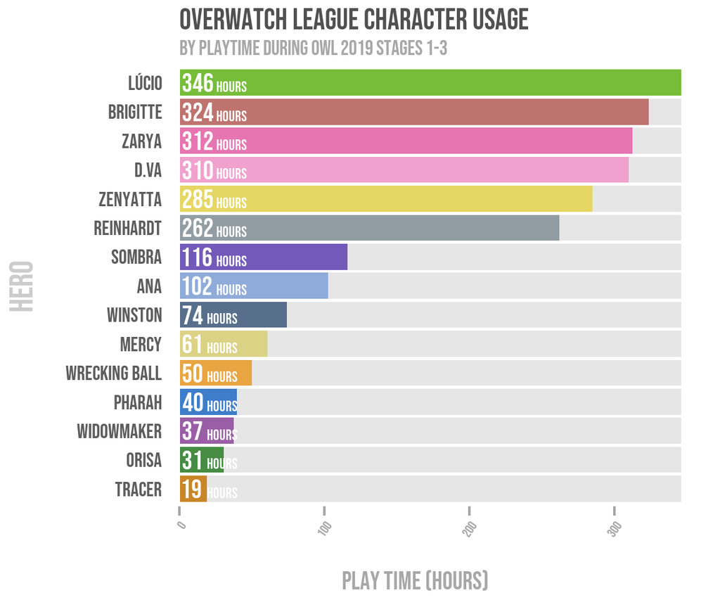

```r
#Display graph
print(graph)
```

### Saving Plot

I encountered an issue with preserving custom fonts when saving the plot, which was fixed by plotting to a windows graphics device using windows() before saving this output as a .png. However, I am unable to test whether this fix would work on other operating systems, as I currently only have access to windows. Nevertheless, my research suggests the quartz() command is a possible fix to replace windows() for mac users.

```r
#Save plot to figs folder
windows(width = 1200, height = 1200)   #Open windows graphics device
print(graph)
dev.print(file = here("figs", "PlayTimeGraph.png"), device = png, width = 1200, height = 1200)


  #Possible alternate fix for mac operating systems to preserve font
  quartz(width = 1200, height = 1200)
  print(graph)
  quartz_save(file = here("figs", "PlayTimeGraph.png"), type = "png", dpi = 300)
```

## Conclusion Part 1

### Interpretation

The plot shows a notable difference between the play time of the top 6 heroes compared to the rest of the 30-hero roster. In combination with the knowledge that the GOATS strategy contains these same top 6 most popular heroes: Lucio, Brigitte, Zarya, D.Va, Zenyatta, and Reinhardt, this suggests that the popularity of this single strategy dominated the competitive Overwatch scene during 2019.

### Possible follow-ups or extensions

The interpretation of the plot, suggesting the popularity of this single strategy, could be tested by plotting the play times of heroes with each other hero on the same team. The expectation is that the top 6 heroes were played significantly more together than when paired with any of the rest of the hero roster. Equally, the popularity of the strategy in a competitive environment suggests its strength. Thus, win rate of heroes should correspond to play time, and popularity. However, the information required to plot both of these could not be extracted from the dataset available.

Furthermore, an animated plot could accommodate visualizing changes in hero popularity distribution over the duration of 2019 OWL, and the effect of title matches (finals) on hero popularity distribution. This may show shifts in popularity of the strategy over time, and depending on the stage of the tournament.

## Animated Visualization

Play time data was grouped by both stage and hero, and previously saved functions were used to prepare the data to be plotted.

```r
library(gganimate)
library(gifski)

#Obtain data to plot play time by season from combined dataset using previously created functions
stagePlayTimeData <- heroData[heroData$stat_name == "Time Played", ] %>%
  group_by(stage, hero) %>%
  summarise(play_time = sum(stat_amount)) %>%
  ungroup() %>%
  clean_pt() %>%
  add_colour()

#Calculate total playtime in each season
stageTime <- heroData[heroData$stat_name == "Time Played", ] %>%
  group_by(stage) %>%
  summarise(play_time = sum(stat_amount)) %>%
  ungroup() %>%
  clean_pt()

#Divide hero play times by total playtime for the corresponding season, giving a percentage of total season play time the hero was used
j = 0
for (s in stagePlayTimeData$stage){
  j = j + 1
    srow <- which(stageTime$stage == s)
    stagePlayTimeData$percent_play_time[j] = (stagePlayTimeData$play_time[j] / stageTime$play_time[srow]) * 100 * 6
}

#Define data to plot
shpt <- ggplot(stagePlayTimeData, aes(x = hero, y = percent_play_time, fill = hero))

stagePlayTimeData
```

| stage | hero | play_time | rounded_play_time | hero_colour | percent_play_time |
| --- | --- | --- | --- | --- | --- |
| Overwatch League Stage 1 | Lúcio | 1.225883e+02 | 123 | #76bd39 | 94.406993521 |
| Overwatch League Stage 1 | Brigitte | 1.153818e+02 | 115 | #be736e | 88.857127807 |
| Overwatch League Stage 1 | Zenyatta | 1.149664e+02 | 115 | #e6d663 | 88.537237087 |
| Overwatch League Stage 1 | Zarya | 1.124227e+02 | 112 | #e675b1 | 86.578325097 |
| Overwatch League Stage 1 | D.Va | 1.083839e+02 | 108 | #f0a1ce | 83.467944546 |
| Overwatch League Stage 2 | D.Va | 1.017550e+02 | 102 | #f0a1ce | 82.211965295 |
| Overwatch League Stage 2 | Lúcio | 1.004212e+02 | 100 | #76bd39 | 81.134346477 |
| Overwatch League Stage 1 | Reinhardt | 9.419492e+01 | 94 | #929da3 | 72.540845848 |
| Overwatch League Stage 3 | Lúcio | 9.223353e+01 | 92 | #76bd39 | 75.937994971 |
| Overwatch League Stage 2 | Brigitte | 9.204803e+01 | 92 | #be736e | 74.369304542 |

[output cut: 160 more lines]

### Animated Bar Plot

Because the data does not smoothly correlate between states, I decided not to reorder the plot for each state to reduce confusion in the visualization. This has the downside of making it harder to view the specific popularity ranking of each hero. Similarly, a line graph may be more appropriate to show changes in popularity over time. However, the main purpose of this visualization is to view the formation of a meta, and thus visualize the gap in popularity between meta and non-meta heroes, which a bar chart better achieves. For similar reasons, all heroes were included in the graph, as the top 15 heroes did not remain constant - as in the previous plot.

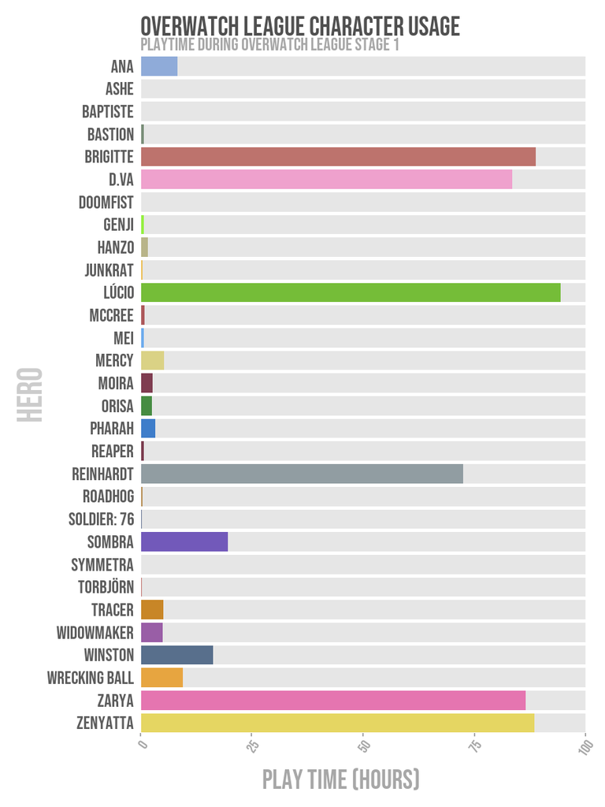

```r
#Plot graph and customize various plot aesthetics
staticAnimGraph <- shpt +
  geom_bar(stat = "identity", show.legend = FALSE) +
  scale_y_continuous(limits = c(0, 100), expand = c(0, 0)) +
  scale_x_discrete(limits = rev, expand = c(0, 0)) +
  xlab("HERO") +
  ylab("PLAY TIME (hours)") +
  labs(title = "Overwatch League Character Usage", subtitle = ("playtime during {closest_state}"), size = 40) +
  theme_bw() +
  coord_flip() +
  scale_fill_manual(values = playTimeData$hero_colour, limits = playTimeData$hero) +
  geom_vline(xintercept = seq(1.5, length = 32), lwd = 2, colour = "white") +
  geom_vline(xintercept = seq(-1.5, length = 32), lwd = 2, colour = "white") +
  theme(panel.border = element_blank(),
        panel.grid.major = element_blank(),
        panel.grid.minor = element_blank(),
        plot.margin = unit(c(1, 1, 1, 1), "cm"),
        axis.line = element_line(colour = backgroundColour),
        plot.background = element_rect(fill = backgroundColour),
        panel.background = element_rect(fill = "#e6e6e6"),
        text = element_text(family = "Bebas Neue", colour = textColour),
        plot.title = element_text(size = 30, colour = "#505050", vjust = 2),
        plot.subtitle = element_text(size = 20, colour = textColourFaded),
        axis.title.x = element_text(size = 30, margin = margin(t=20), colour = textColourFaded, hjust = 0.42),
        axis.title.y = element_text(size = 40, margin = margin(r=19), colour = "#5c5c5c4f"),
        axis.ticks.x = element_line(colour = textColourFaded, size = 0.8),
        axis.ticks.y = element_blank(),
        axis.ticks.length.x = unit(0.2, "cm"),
        axis.ticks.length.y = unit(0.3, "cm"),
        axis.text.x = element_text(colour = textColourFaded, size = 16, angle = 55, vjust = 0.9, hjust = 0.95),
        axis.text.y = element_text(colour = textColour, size = 20)) +
        transition_states(stage, transition_length = 2, state_length = 3)

#Render the animated graph as gif and save to figs folder
animate(staticAnimGraph, 200, fps = 20, width = 900, height = 1200,
        renderer = gifski_renderer(here("figs", "SeasonPlayTimeGraph.gif")))
```

## Conclusion Part 2

### Interpretation

The strategy appears to remain dominant throughout most of 2019. However towards the end, during OWL stage 3 and its title matches, the gap between the popularity of the top 6 heroes is dramatically reduced, suggesting the introduction of a ‘role lock’ may not have been necessary to increase the variation in hero picks within the game. Thus, this decision by the developers may have been an unnecessary detriment to the game’s popularity in the years after 2019.

Additionally the difference between play times of the top 6 heroes and the other 24 seems larger in title matches for stages 1 and 2, indicating either less experimentation by teams, or that teams using the meta GOATS composition were the ones that reached the finals, suggesting it’s strength over the other compositions.

### Possible Follow-ups or Extensions

Hero pick distribution could be plotted against viewer amounts for the respective stages, investigating a possible link between game popularity and hero pick variety.